# ggplot2_solutions_chapter10

Nade Kang

July 13, 2018

# Solution Manual for ggplot2 Elegant Graphics for Data Analysis by Hadley Wickham

# ggplot2 Chpater 10 Data Transformation

## *Exercise 10.2.3*

### Load Packages

```r
library(tidyverse)
library(ggthemes)
```

*Question 1* Practice your filtering skills by: - Finding all the diamonds with equal x and y dimensions.

```r
diamonds_xey <- filter(diamonds, x == y)
head(diamonds_xey)
```

```
## # A tibble: 6 x 10
##   carat cut       color clarity depth table price     x     y     z
##   <dbl> <ord>     <ord> <ord>   <dbl> <dbl> <int> <dbl> <dbl> <dbl>
## 1  0.3  Ideal     H     VVS2     62.5    54   567  4.3   4.3   2.7
## 2  0.27 Very Good F     VVS1     62      55   591  4.16  4.16  2.59
## 3  1    Very Good H     VS2      63.3    53  5139  0     0     0
## 4  1.14 Fair      G     VS1      57.5    67  6381  0     0     0
## 5  1    Premium   E     VS2      60      60  6600  6.43  6.43  3.89
## 6  1    Premium   E     VS2      60      60  6720  6.43  6.43  3.89
```

- A depth between 55 and 70. Here, depth refers to the value z. Assuming the between means inclusive:

```r
diamonds_z5570 <- diamonds %>% filter(z >= 55 & z <= 70)
head(diamonds_z5570)
```

```
## # A tibble: 0 x 10
## # ... with 10 variables: carat <dbl>, cut <ord>, color <ord>,
## #   clarity <ord>, depth <dbl>, table <dbl>, price <int>, x <dbl>,
## #   y <dbl>, z <dbl>
```

So there is no such diamond that has a depth between 55 and 70.

- A carat smaller than the median carat.

```r
dia_cara_lessmedian <- filter(diamonds, carat < median(diamonds$carat))
head(dia_cara_lessmedian)
```

```
## # A tibble: 6 x 10
##   carat cut       color clarity depth table price     x     y     z
##   <dbl> <ord>     <ord> <ord>   <dbl> <dbl> <int> <dbl> <dbl> <dbl>
## 1 0.23  Ideal     E     SI2      61.5    55   326  3.95  3.98  2.43
## 2 0.21  Premium   E     SI1      59.8    61   326  3.89  3.84  2.31
## 3 0.23  Good      E     VS1      56.9    65   327  4.05  4.07  2.31
## 4 0.290 Premium   I     VS2      62.4    58   334  4.2   4.23  2.63
## 5 0.31  Good      J     SI2      63.3    58   335  4.34  4.35  2.75
## 6 0.24  Very Good J     VVS2     62.8    57   336  3.94  3.96  2.48
```

- Cost more than $10,000 per carat

```r
more10000pc <- filter(diamonds, price/carat > 10000)
head(more10000pc)
```

```
## # A tibble: 6 x 10
##   carat cut       color clarity depth table price     x     y     z
##   <dbl> <ord>     <ord> <ord>   <dbl> <dbl> <int> <dbl> <dbl> <dbl>
## 1  0.63 Ideal     D     IF       62.5    55  6549  5.47  5.5   3.43
## 2  0.63 Ideal     D     IF       62.5    55  6607  5.5   5.47  3.43
## 3  0.9  Very Good D     IF       62.4    54  9182  6.17  6.21  3.86
## 4  0.91 Ideal     E     VVS1     61.7    56  9636  6.18  6.23  3.83
## 5  1    Very Good F     IF       63.2    63 10046  6.26  6.24  3.95
## 6  1    Premium   D     VVS2     61.6    60 10046  6.41  6.36  3.93
```

- Are of good or better quality Are of good or better means excluding fiar:

```r
besseralsgut <- filter(diamonds, cut != "Fair")
head(besseralsgut)
```

```
## # A tibble: 6 x 10
##   carat cut       color clarity depth table price     x     y     z
##   <dbl> <ord>     <ord> <ord>   <dbl> <dbl> <int> <dbl> <dbl> <dbl>
## 1 0.23  Ideal     E     SI2      61.5    55   326  3.95  3.98  2.43
## 2 0.21  Premium   E     SI1      59.8    61   326  3.89  3.84  2.31
## 3 0.23  Good      E     VS1      56.9    65   327  4.05  4.07  2.31
## 4 0.290 Premium   I     VS2      62.4    58   334  4.2   4.23  2.63
## 5 0.31  Good      J     SI2      63.3    58   335  4.34  4.35  2.75
## 6 0.24  Very Good J     VVS2     62.8    57   336  3.94  3.96  2.48
```

*Question 2* Fill in the question marks in this table:

Didn’t understand this table, waiting for help from Stack Overflow.

*Question 3* Repeat the analysis of outlying values with z. Compared to x and y, how would you characterise the relationship of x and z, or y and z?

We make a first plot to take a look at the data:

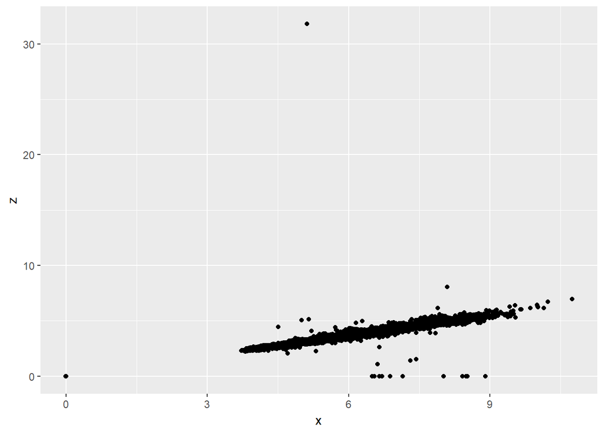

```r
ggplot(diamonds, aes(x, z)) +
  geom_jitter()
```

Then we know to extract x > 0 and z > 0, with z < 10:

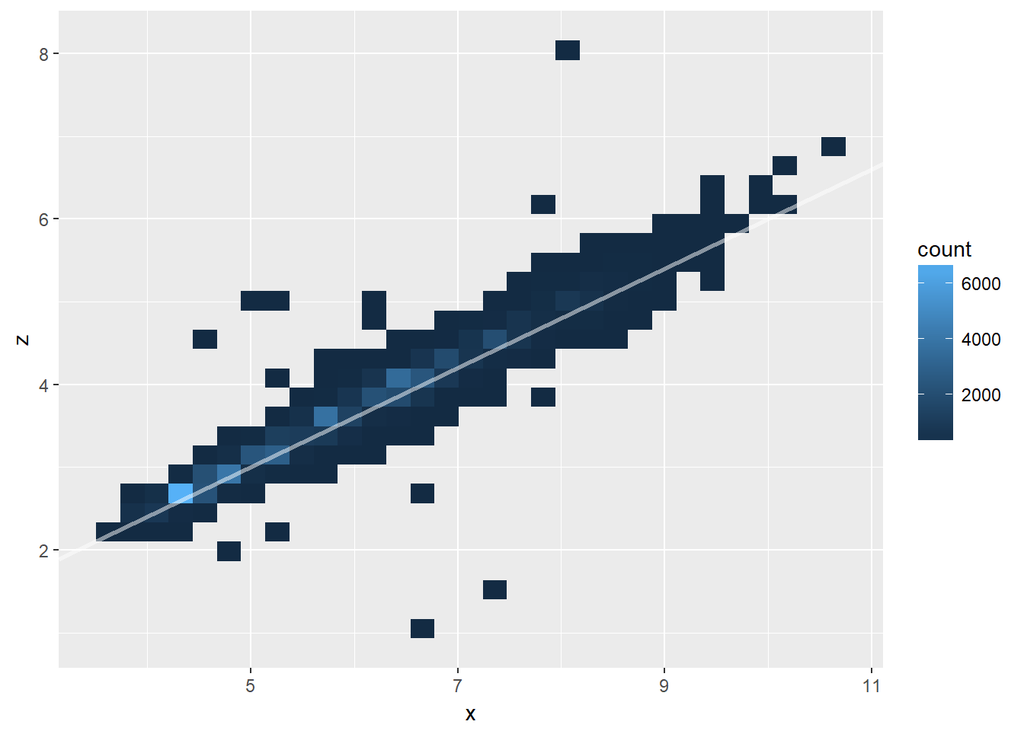

```r
diamonds_zok <- filter(diamonds, x > 0, z > 0, z < 10)
ggplot(diamonds_zok, aes(x, z)) +
  geom_bin2d() +
  geom_abline(slope = 0.6, color = "white", size = 1, alpha = 0.5)
```

Despite the outliers, there seems to be a positive replationship between x and z.  
Now let’s take a look at y and z:

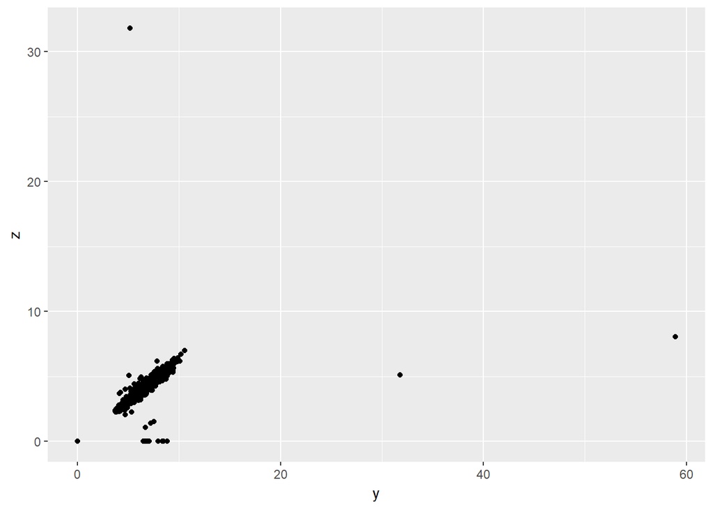

```r
ggplot(diamonds, aes(y, z)) +
  geom_jitter()
```

We need to extract 0 < z < 10 and 0 < y < 15:

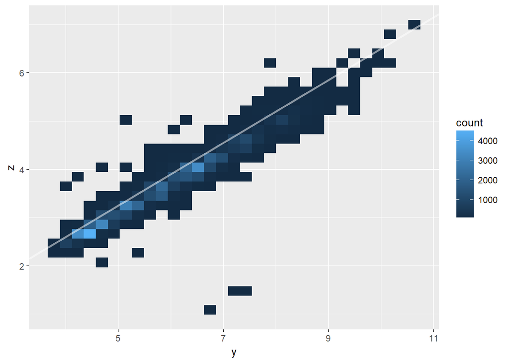

```r
diamonds_yz <- filter(diamonds, z > 0 & z < 10, y > 0 & y < 15)
ggplot(diamonds_yz, aes(y, z)) +
  geom_bin2d() +
  geom_abline(slope = 0.65, color = "white", size = 1, alpha = 0.5)
```

*Question 4* Install the ggplot2movies package and look at the movies that have a missing budget. How are they different from the movies with a budget? (Hint: try a frequency polygon plus colour = is.na(budget).)

```r
library(ggplot2movies)
movies <- ggplot2movies::movies
movies
```

```
## # A tibble: 58,788 x 24
##    title     year length budget rating votes    r1    r2    r3    r4    r5
##    <chr>    <int>  <int>  <int>  <dbl> <int> <dbl> <dbl> <dbl> <dbl> <dbl>
##  1 $         1971    121     NA    6.4   348   4.5   4.5   4.5   4.5  14.5
##  2 $1000 a~  1939     71     NA    6      20   0    14.5   4.5  24.5  14.5
##  3 $21 a D~  1941      7     NA    8.2     5   0     0     0     0     0
##  4 $40,000   1996     70     NA    8.2     6  14.5   0     0     0     0
##  5 $50,000~  1975     71     NA    3.4    17  24.5   4.5   0    14.5  14.5
##  6 $pent     2000     91     NA    4.3    45   4.5   4.5   4.5  14.5  14.5
##  7 $windle   2002     93     NA    5.3   200   4.5   0     4.5   4.5  24.5
##  8 '15'      2002     25     NA    6.7    24   4.5   4.5   4.5   4.5   4.5
##  9 '38       1987     97     NA    6.6    18   4.5   4.5   4.5   0     0
## 10 '49-'17   1917     61     NA    6      51   4.5   0     4.5   4.5   4.5
## # ... with 58,778 more rows, and 13 more variables: r6 <dbl>, r7 <dbl>,
## #   r8 <dbl>, r9 <dbl>, r10 <dbl>, mpaa <chr>, Action <int>,
## #   Animation <int>, Comedy <int>, Drama <int>, Documentary <int>,
## #   Romance <int>, Short <int>
```

```r
movies2 <- movies %>%
  mutate(hasbudget = ifelse(budget == 0, "Missing Budget", "Has Budget"))
movies2
```

```
## # A tibble: 58,788 x 25
##    title     year length budget rating votes    r1    r2    r3    r4    r5
##    <chr>    <int>  <int>  <int>  <dbl> <int> <dbl> <dbl> <dbl> <dbl> <dbl>
##  1 $         1971    121     NA    6.4   348   4.5   4.5   4.5   4.5  14.5
##  2 $1000 a~  1939     71     NA    6      20   0    14.5   4.5  24.5  14.5
##  3 $21 a D~  1941      7     NA    8.2     5   0     0     0     0     0
##  4 $40,000   1996     70     NA    8.2     6  14.5   0     0     0     0
##  5 $50,000~  1975     71     NA    3.4    17  24.5   4.5   0    14.5  14.5
##  6 $pent     2000     91     NA    4.3    45   4.5   4.5   4.5  14.5  14.5
##  7 $windle   2002     93     NA    5.3   200   4.5   0     4.5   4.5  24.5
##  8 '15'      2002     25     NA    6.7    24   4.5   4.5   4.5   4.5   4.5
##  9 '38       1987     97     NA    6.6    18   4.5   4.5   4.5   0     0
## 10 '49-'17   1917     61     NA    6      51   4.5   0     4.5   4.5   4.5
## # ... with 58,778 more rows, and 14 more variables: r6 <dbl>, r7 <dbl>,
## #   r8 <dbl>, r9 <dbl>, r10 <dbl>, mpaa <chr>, Action <int>,
## #   Animation <int>, Comedy <int>, Drama <int>, Documentary <int>,
## #   Romance <int>, Short <int>, hasbudget <chr>
```

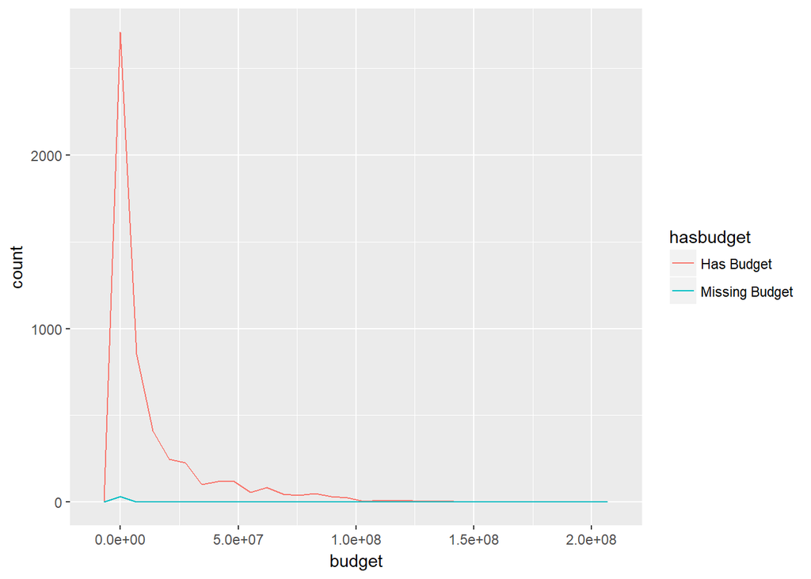

```r
ggplot(movies2, aes(budget)) +
  geom_freqpoly(aes(color = hasbudget))
```

Not quite sure what conclusion can be drawn from here.

*Question 5* What is NA & FALSE and NA | TRUE? Why? Why doesn’t NA * 0 equal zero? What number times zero does not equal 0? What do you expect NA ˆ 0 to equal? Why?

```r
NA & FALSE
```

```
## [1] FALSE
```

```r
# FALSE
NA | TRUE
```

```
## [1] TRUE
```

```r
# TRUE
```

This is because the logical expressions follow the Kleene and Priest logics, view it here: https://en.wikipedia.org/wiki/Three-valued_logic

```r
NA * 0
```

```
## [1] NA
```

```r
# NA
NA ^ 0
```

```
## [1] 1
```

```r
# 1
```

The reason that NA * 0 is not equal to 0 is that x * 0 = NaN is undefined when x = Inf or x = -Inf. But anything with power to 0 is 1.

## *Exercises 10.3.2*

*Question 1* Practice your variable creation skills by creating the following new variables: - The approximate volume of the diamond (using x, y, and z).

Assuming the volume of a diamond is approximately 2/3 of a cubic with approximately the same parameters:

```r
diamonds_q1 <- diamonds %>%
  mutate(vol = x * y * z *(2/3))
head(select(diamonds_q1, carat, cut, x:z, vol))
```

```
## # A tibble: 6 x 6
##   carat cut           x     y     z   vol
##   <dbl> <ord>     <dbl> <dbl> <dbl> <dbl>
## 1 0.23  Ideal      3.95  3.98  2.43  25.5
## 2 0.21  Premium    3.89  3.84  2.31  23.0
## 3 0.23  Good       4.05  4.07  2.31  25.4
## 4 0.290 Premium    4.2   4.23  2.63  31.1
## 5 0.31  Good       4.34  4.35  2.75  34.6
## 6 0.24  Very Good  3.94  3.96  2.48  25.8
```

- The approximate density of the diamond. One carat is about 0.2 gram, and to calculate density, density is gram/cm^3:

```r
diamonds_q1 <- diamonds_q1 %>%
  mutate(density = carat * 0.2 / vol)
head(select(diamonds_q1, carat, cut, vol, density))
```

```
## # A tibble: 6 x 4
##   carat cut         vol density
##   <dbl> <ord>     <dbl>   <dbl>
## 1 0.23  Ideal      25.5 0.00181
## 2 0.21  Premium    23.0 0.00183
## 3 0.23  Good       25.4 0.00181
## 4 0.290 Premium    31.1 0.00186
## 5 0.31  Good       34.6 0.00179
## 6 0.24  Very Good  25.8 0.00186
```

- The price per carat. Price per carat is simply price/carat

```r
diamonds_q1 <- diamonds_q1 %>%
  mutate(pricepc = price/carat)
head(select(diamonds_q1, carat, price, vol, density, pricepc))
```

```
## # A tibble: 6 x 5
##   carat price   vol density pricepc
##   <dbl> <int> <dbl>   <dbl>   <dbl>
## 1 0.23    326  25.5 0.00181   1417.
## 2 0.21    326  23.0 0.00183   1552.
## 3 0.23    327  25.4 0.00181   1422.
## 4 0.290   334  31.1 0.00186   1152.
## 5 0.31    335  34.6 0.00179   1081.
## 6 0.24    336  25.8 0.00186   1400
```

- Log transformation of carat and price.

```r
diamonds_q1 <- diamonds_q1 %>%
  mutate(caratl = log2(carat),
         pricel = log2(price))
head(select(diamonds_q1, carat, price, caratl, pricel))
```

```
## # A tibble: 6 x 4
##   carat price caratl pricel
##   <dbl> <int>  <dbl>  <dbl>
## 1 0.23    326  -2.12   8.35
## 2 0.21    326  -2.25   8.35
## 3 0.23    327  -2.12   8.35
## 4 0.290   334  -1.79   8.38
## 5 0.31    335  -1.69   8.39
## 6 0.24    336  -2.06   8.39
```

*Question 2* How can you improve the data density of ggplot(diamonds, aes(x, z)) + stat bin2d(). What transformation makes it easier to extract outliers?

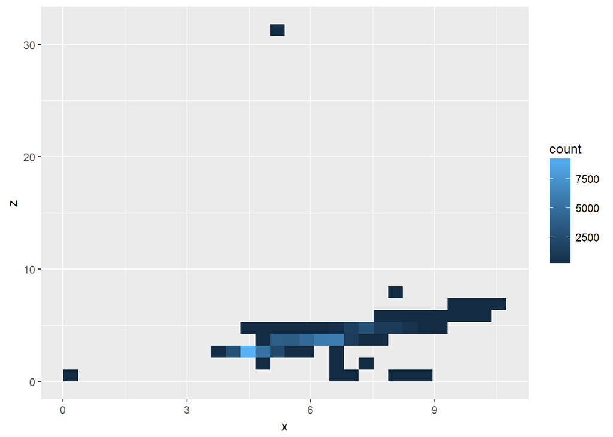

```r
ggplot(diamonds, aes(x, z)) +
  stat_bin2d()
```

I am not quite sure about what the question is asking for.

*Question 3* The depth variable is just the width of the diamond (average of x and y) divided by its height (z) multiplied by 100 and round to the nearest integer. Compute the depth yourself and compare it to the existing depth variable. Summarise your findings with a plot.

Depth is calculated as height(z) divided by width (avg of x and y) times 100. There is expression mistake in the question.

```r
diamonds_q1 <- diamonds_q1 %>%
  mutate(depth_cal = round(z / ((x + y)/2) * 100))
head(select(diamonds_q1, depth_cal, depth))
```

```
## # A tibble: 6 x 2
##   depth_cal depth
##       <dbl> <dbl>
## 1        61  61.5
## 2        60  59.8
## 3        57  56.9
## 4        62  62.4
## 5        63  63.3
## 6        63  62.8
```

Make a plot: We calculate the difference between the given depth and our calculated depth_cal, then we make a plot, if the plots shows more positive values, then it means our calculation is below the original, otherwise, above.

```r
diamonds_q1 <- diamonds_q1 %>%
  mutate(diff = depth - depth_cal,
         seq = seq_along(carat))
diamonds_q1
```

```
## # A tibble: 53,940 x 18
##    carat cut       color clarity depth table price     x     y     z   vol
##    <dbl> <ord>     <ord> <ord>   <dbl> <dbl> <int> <dbl> <dbl> <dbl> <dbl>
##  1 0.23  Ideal     E     SI2      61.5    55   326  3.95  3.98  2.43  25.5
##  2 0.21  Premium   E     SI1      59.8    61   326  3.89  3.84  2.31  23.0
##  3 0.23  Good      E     VS1      56.9    65   327  4.05  4.07  2.31  25.4
##  4 0.290 Premium   I     VS2      62.4    58   334  4.2   4.23  2.63  31.1
##  5 0.31  Good      J     SI2      63.3    58   335  4.34  4.35  2.75  34.6
##  6 0.24  Very Good J     VVS2     62.8    57   336  3.94  3.96  2.48  25.8
##  7 0.24  Very Good I     VVS1     62.3    57   336  3.95  3.98  2.47  25.9
##  8 0.26  Very Good H     SI1      61.9    55   337  4.07  4.11  2.53  28.2
##  9 0.22  Fair      E     VS2      65.1    61   337  3.87  3.78  2.49  24.3
## 10 0.23  Very Good H     VS1      59.4    61   338  4     4.05  2.39  25.8
## # ... with 53,930 more rows, and 7 more variables: density <dbl>,
## #   pricepc <dbl>, caratl <dbl>, pricel <dbl>, depth_cal <dbl>,
## #   diff <dbl>, seq <int>
```

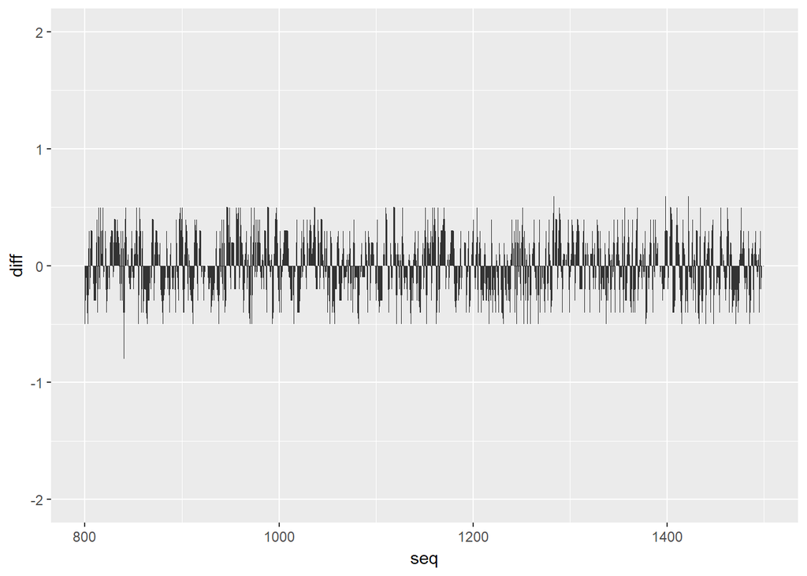

```r
ggplot(diamonds_q1) +
  geom_area(aes(x = seq, y = diff)) +
  xlim(800, 1500) + ylim(-2, 2)
```

You can adjust the xlim and ylim to zoom in different areas of the plot to take a look. Here only offers one set of values for an example.

*Question 4* Compare the distribution of symmetry for diamonds with x > y vs. x < y.

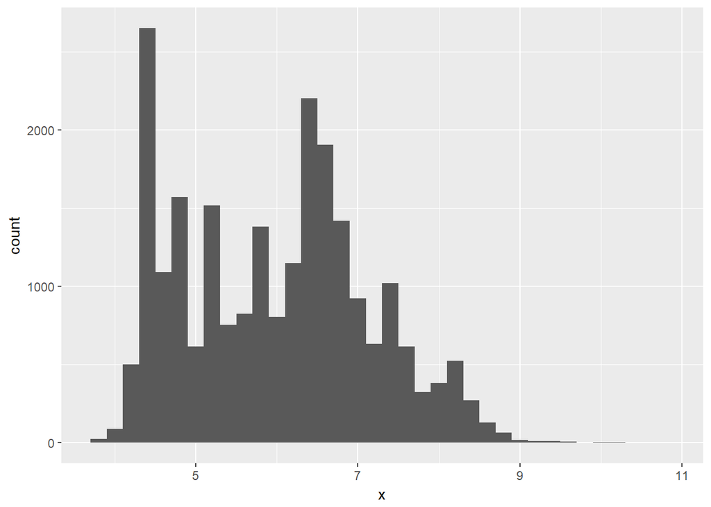

```r
diamonds_q1 %>%
  filter(x > y) %>%
  ggplot(aes(x)) +
  geom_bar(binwidth = 0.2)
```

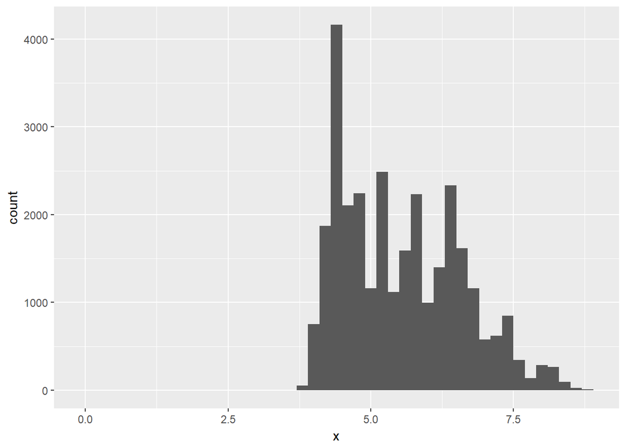

```r
diamonds_q1 %>%
  filter(y > x) %>%
  ggplot(aes(x)) +
  geom_bar(binwidth = 0.2)
```

## *Exercises 10.4.3*

*Question 1* For each year in the ggplot2movies::movies data determine the percent of movies with missing budgets. Visualise the result.

```r
movies <- ggplot2movies::movies
View(movies)
```

We need to create a boolean column called with_budget, so if the movie has a budget, we place TRUE, else we place FALSE

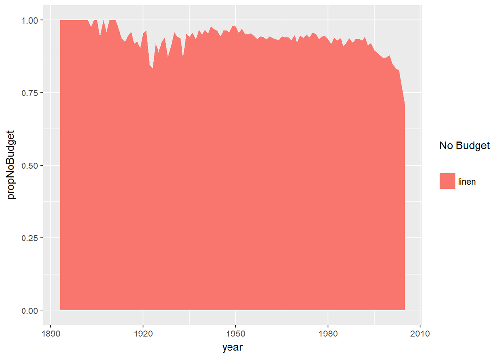

```r
movies1 <- movies %>%
  mutate(with_budget = ifelse(is.na(budget), FALSE, TRUE)) %>%
  group_by(year) %>%
  summarise(
    hasBudget = sum(with_budget),
    total = n(),
    propNoBudget = 1 - hasBudget/total
  )
ggplot(movies1, aes(year, propNoBudget)) +
  geom_area(aes(fill = "linen")) +
  labs(fill = expression(atop("No Budget"))) +
  theme(legend.title = element_text(vjust = 0))
```

```r
movies1
```

```
## # A tibble: 113 x 4
##     year hasBudget total propNoBudget
##    <int>     <int> <int>        <dbl>
##  1  1893         0     1            1
##  2  1894         0     9            1
##  3  1895         0     3            1
##  4  1896         0    13            1
##  5  1897         0     9            1
##  6  1898         0     5            1
##  7  1899         0     9            1
##  8  1900         0    16            1
##  9  1901         0    28            1
## 10  1902         0     9            1
## # ... with 103 more rows
```

As you can see from the plot, the percentage of movies with missing budget decreased with the progression of time.

*Question 2* How does the average length of a movie change over time? Display your answer with a plot, including some display of uncertainty.

We only need to group the data by year, and then calculate the mean of length, then use a line plot (since we have time and a continuous variable).

```r
q2 <- movies %>%
  group_by(year) %>%
  summarise(mean = mean(length))
q2
```

```
## # A tibble: 113 x 2
##     year  mean
##    <int> <dbl>
##  1  1893  1
##  2  1894  1
##  3  1895  1
##  4  1896  1.31
##  5  1897  1
##  6  1898  1
##  7  1899  2.44
##  8  1900  1.44
##  9  1901  2
## 10  1902  3.56
## # ... with 103 more rows
```

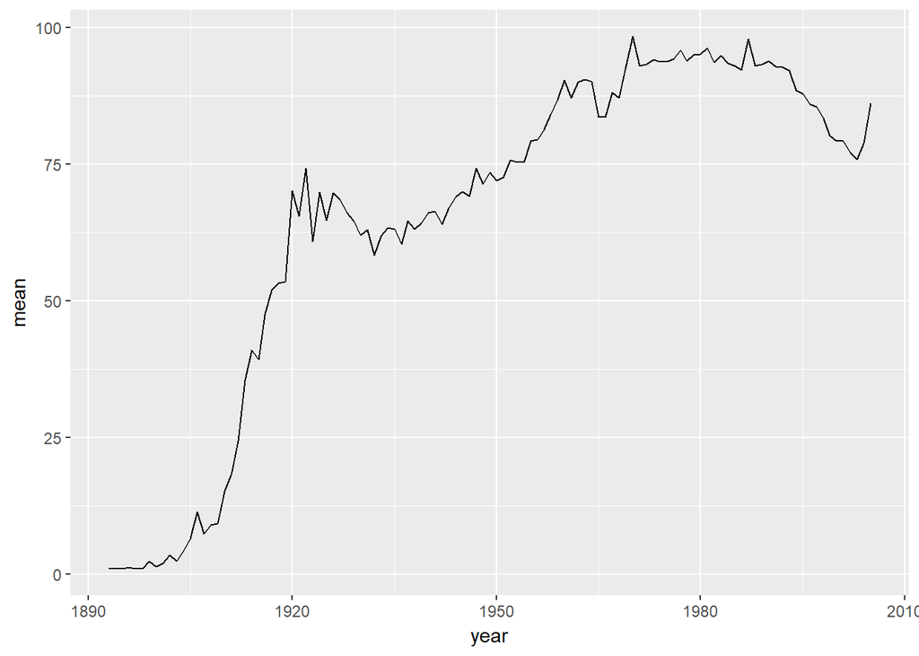

```r
ggplot(q2, aes(year, mean)) +
  geom_line()
```

*Question 3* For each combination of diamond quality (e.g. cut, colour and clarity), count the number of diamonds, the average price and the average size. Visualise the results.

Assume size means depth

```r
diamonds_q3 <- diamonds %>%
  group_by(cut) %>%
  summarise(
    number = n(),
    avgprice = mean(price),
    avgsize = mean(depth)
  )
diamonds_q3
```

```
## # A tibble: 5 x 4
##   cut       number avgprice avgsize
##   <ord>      <int>    <dbl>   <dbl>
## 1 Fair        1610    4359.    64.0
## 2 Good        4906    3929.    62.4
## 3 Very Good  12082    3982.    61.8
## 4 Premium    13791    4584.    61.3
## 5 Ideal      21551    3458.    61.7
```

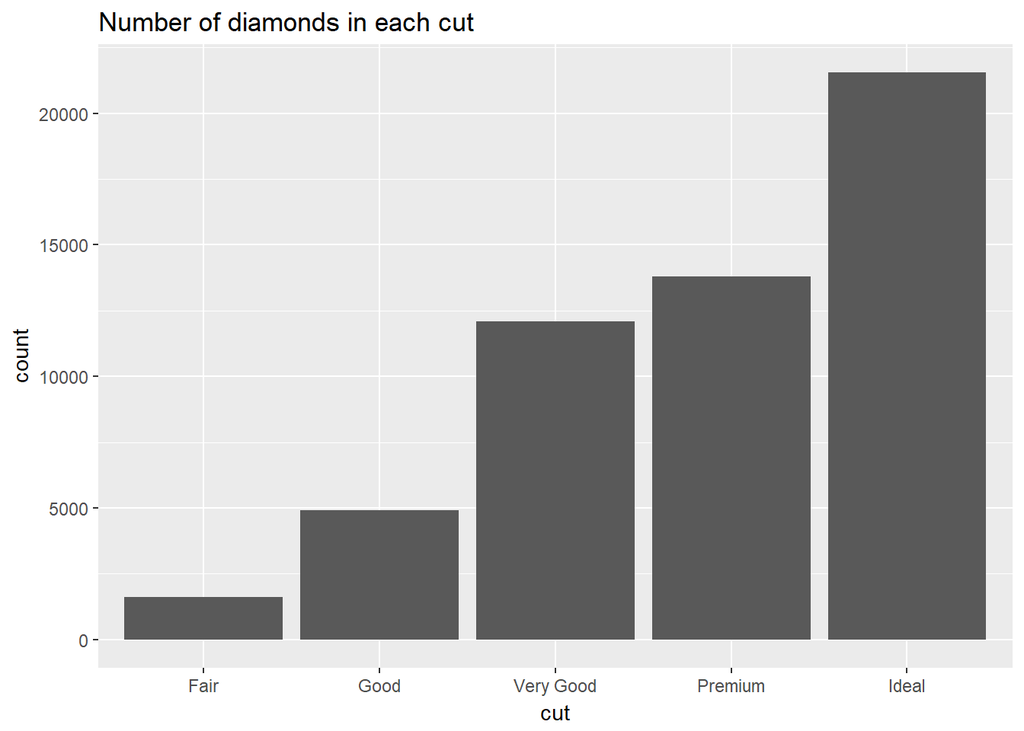

```r
ggplot(diamonds, aes(cut)) +
  geom_bar() +
  ggtitle("Number of diamonds in each cut")
```

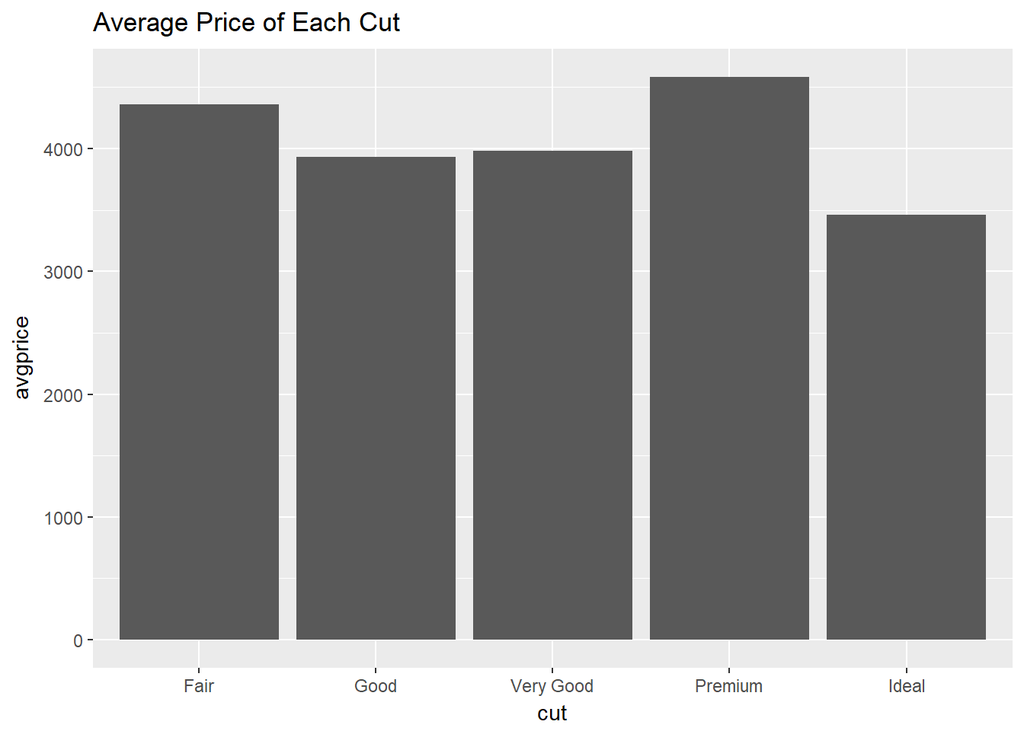

```r
ggplot(diamonds_q3, aes(cut, avgprice)) +
  geom_bar(stat = "identity") +
  ggtitle("Average Price of Each Cut")
```

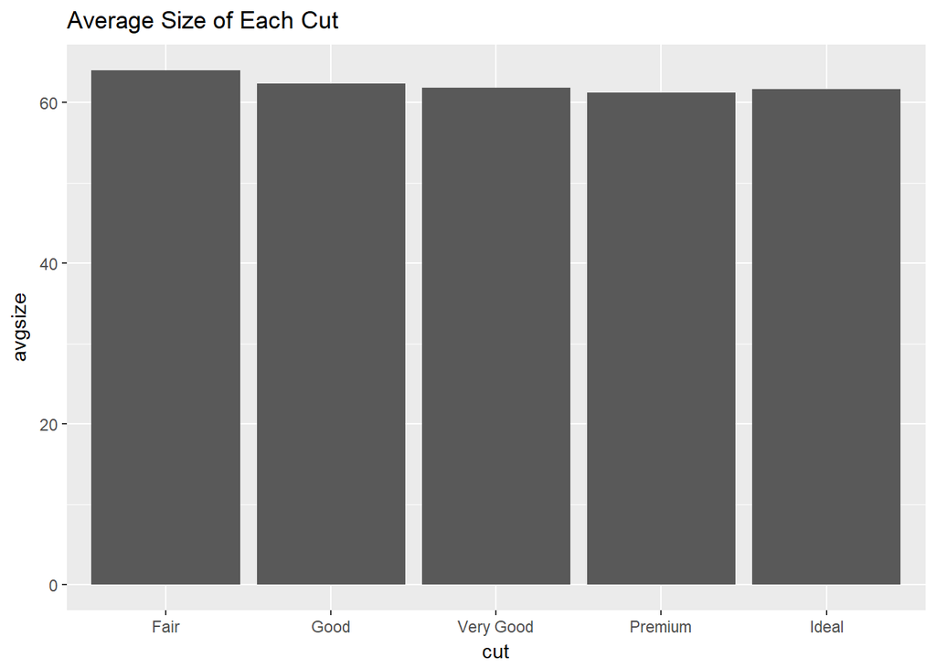

```r
ggplot(diamonds_q3, aes(cut, avgsize)) +
  geom_bar(stat = "identity") +
  ggtitle("Average Size of Each Cut")
```

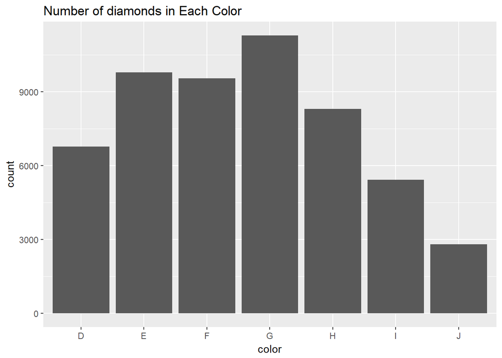

```r
diamonds_q3 <- diamonds %>%
  group_by(color) %>%
  summarise(
    number = n(),
    avgprice = mean(price),
    avgsize = mean(depth)
  )

ggplot(diamonds, aes(color)) +
  geom_bar() +
  ggtitle("Number of diamonds in Each Color")
```

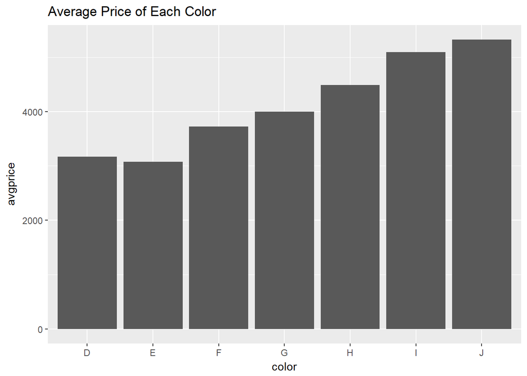

```r
ggplot(diamonds_q3, aes(color, avgprice)) +
  geom_bar(stat = "identity") +
  ggtitle("Average Price of Each Color")
```

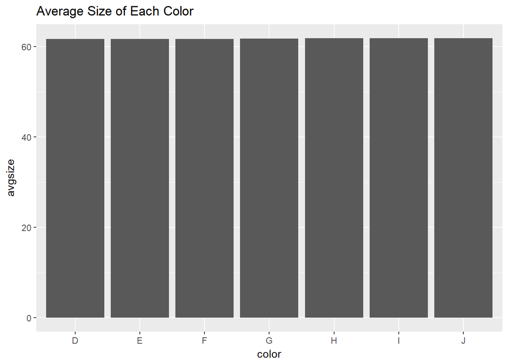

```r
ggplot(diamonds_q3, aes(color, avgsize)) +
  geom_bar(stat = "identity") +
  ggtitle("Average Size of Each Color")
```

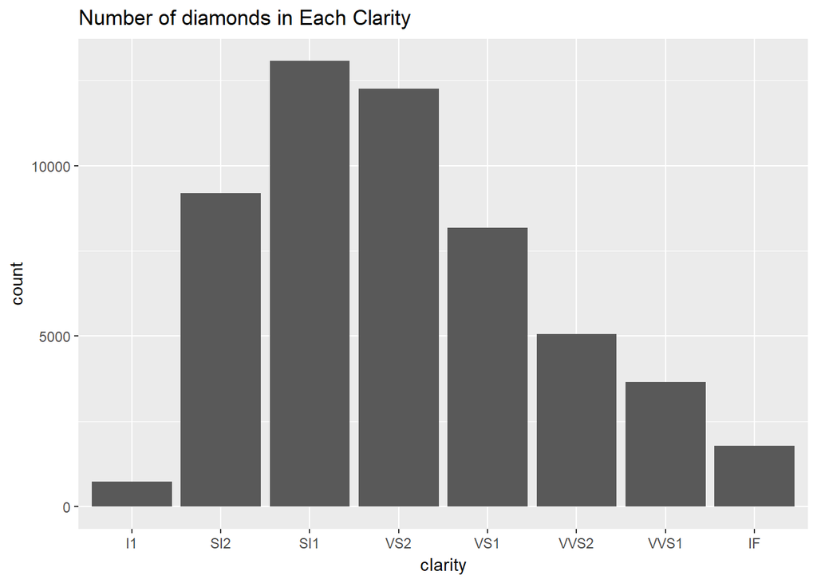

```r
diamonds_q3 <- diamonds %>%
  group_by(clarity) %>%
  summarise(
    number = n(),
    avgprice = mean(price),
    avgsize = mean(depth)
  )

ggplot(diamonds, aes(clarity)) +
  geom_bar() +
  ggtitle("Number of diamonds in Each Clarity")
```

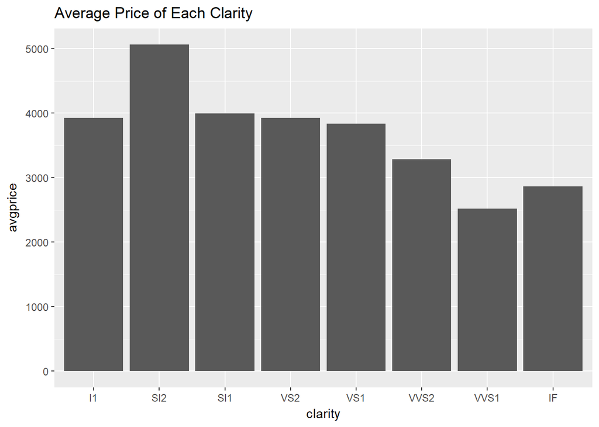

```r
ggplot(diamonds_q3, aes(clarity, avgprice)) +
  geom_bar(stat = "identity") +
  ggtitle("Average Price of Each Clarity")
```

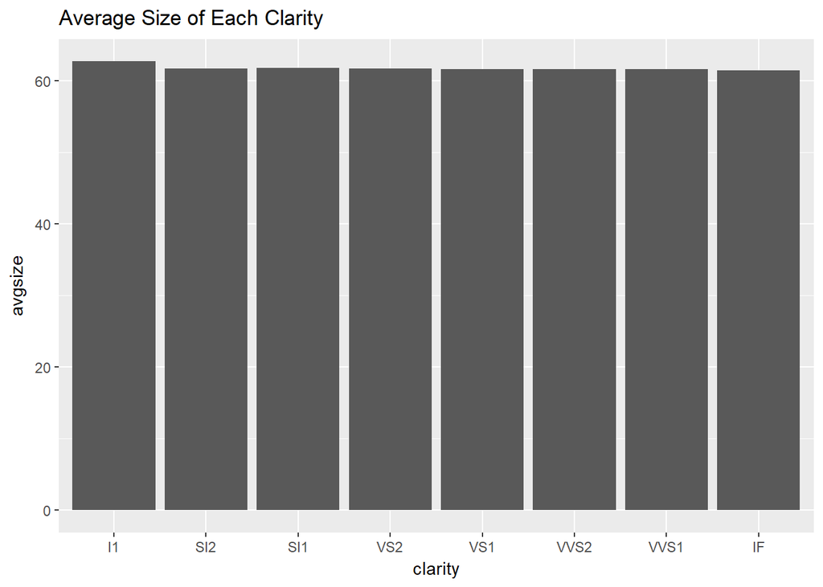

```r
ggplot(diamonds_q3, aes(clarity, avgsize)) +
  geom_bar(stat = "identity") +
  ggtitle("Average Size of Each Clarity")
```

*Question 4* Compute a histogram of carat by “hand” using a binwidth of 0.1. Display the results with geom bar(stat = “identity”). (Hint: you might need to create a new variable first.)

Not sure about the best way to compute by hand.

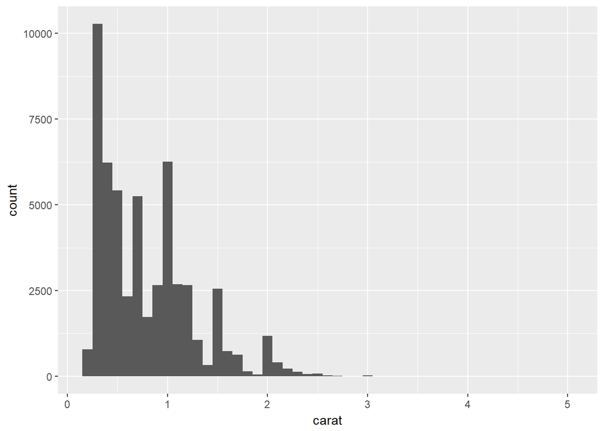

```r
ggplot(diamonds, aes(carat)) +
  geom_histogram(binwidth = 0.1)
```

*Question 5* In the baseball example, the batting average seems to increase as the number of at bats increases. Why?

Not familiar with baseball, but practice makes perfect?

## *Exercises 10.5.1*

*Question 1* Translate each of the examples in this chapter to use the pipe.

Most of my codes above used pipes, but each example is too much.

*Question 2* What does the following pipe do?

```r
library(magrittr)
x <- runif(100)
x %>%
subtract(mean(.)) %>%
raise_to_power(2) %>%
mean() %>%
sqrt()
```

*Question 3* Which player in the Batting dataset has had the most consistently good performance over the course of their career?

Not familiar with baseball, and choose the criteria, group the data by player, arrange criteria in decending order.